# Berlin Borough Survey: CPA vs CPM Source Comparison

January 29, 2026

# Executive Summary

This report compares two identical Berlin borough surveys sourced differently: **CPA** (Cost Per Acquisition) vs **CPM** (Cost Per Mille / impression-based). Both used the same questionnaire; the only difference is respondent sourcing method.

**Weighting dimensions** (Berlin-wide ANES raking): Age $\times$ Gender (6 cells), Education (ISCED 5+ vs Rest), and Borough (12 districts). BTW 2025 vote recall is **not** used as a weighting variable — it is shown for comparison only.

- **CPA**: 335 valid Berlin adults from 574 responses (58% yield). Design effect 2.29, effective n = 146.
- **CPM**: 204 valid Berlin adults from 333 responses (61% yield). Design effect 2.08, effective n = 98.

# Sample and Weighting Diagnostics

| Metric | CPA | CPM |
| --- | --- | --- |
| Total responses | 574 | 333 |
| Valid Berlin adults | 335 | 204 |
| Yield (%) | 58% | 61% |
| Complete cases (weighting) | 335 | 204 |
| Design effect | 2.29 | 2.08 |
| Effective n | 146 | 98 |
| Weight CV | 1.14 | 1.04 |

**Interpretation**: A higher design effect means the weighting had to do more work to correct sample imbalances, which reduces effective sample size. A design effect of 1.0 would mean no correction was needed.

## Representativeness: Distance from Berlin Targets

| Raking Dimension | CPA (pp) | CPM (pp) | Closer to Target |
| --- | --- | --- | --- |
| Age | 20.0 | 17.0 | CPM |
| Gender | 19.9 | 21.7 | CPA |
| Borough | 1.9 | 2.0 | CPA |
| Education | 4.3 | 6.6 | CPA |
| Vote Recall (BTW 2025)* | 4.8 | 5.1 | CPA |

Mean absolute deviation (pp) from Berlin population targets per dimension, computed on unweighted samples. *Vote Recall is not a weighting variable.

# Unweighted Demographic Distributions

These plots compare the raw (unweighted) sample composition of CPA vs CPM. Differences show how the two sourcing methods naturally attract different respondent profiles.

## Age

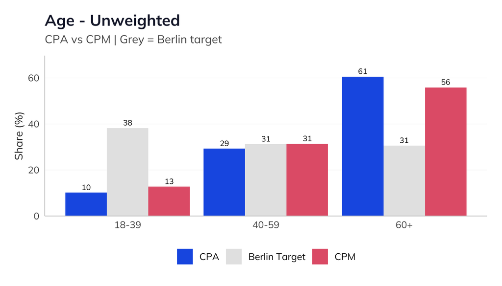

## Gender

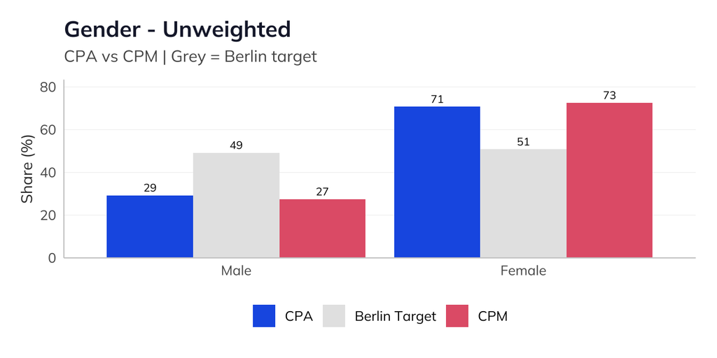

## Borough

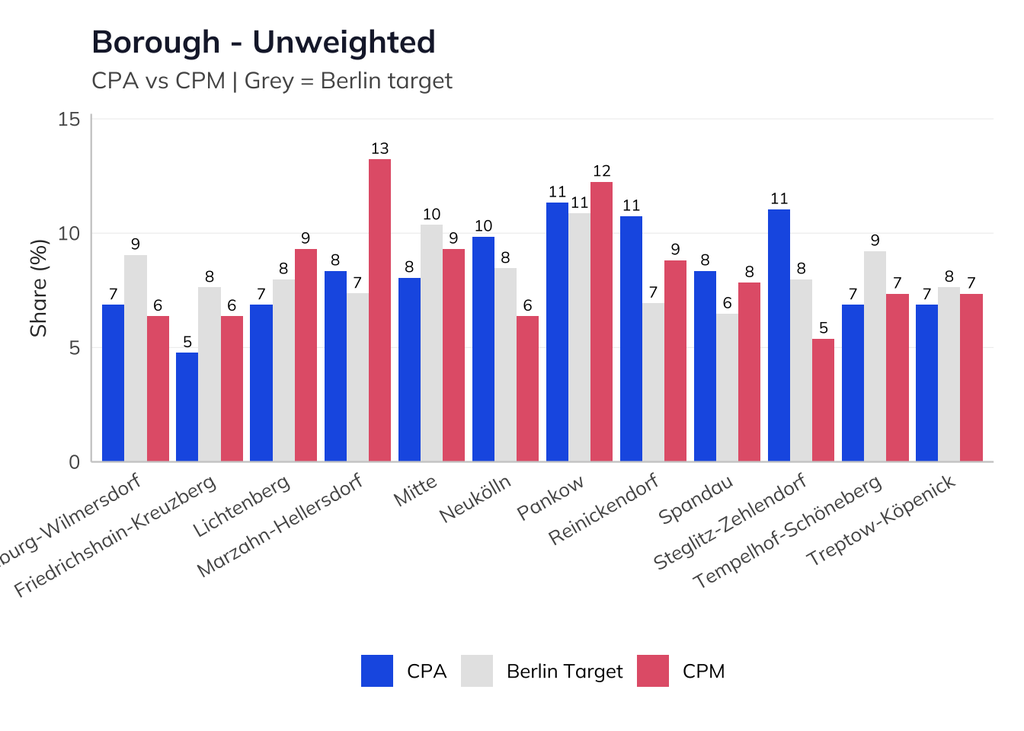

## Education

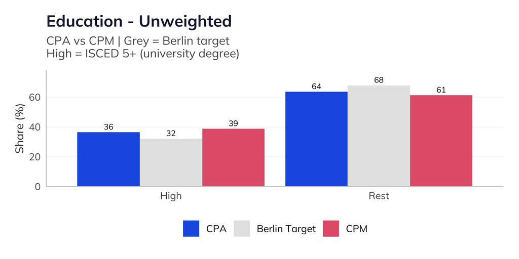

## BTW 2025 Vote Recall

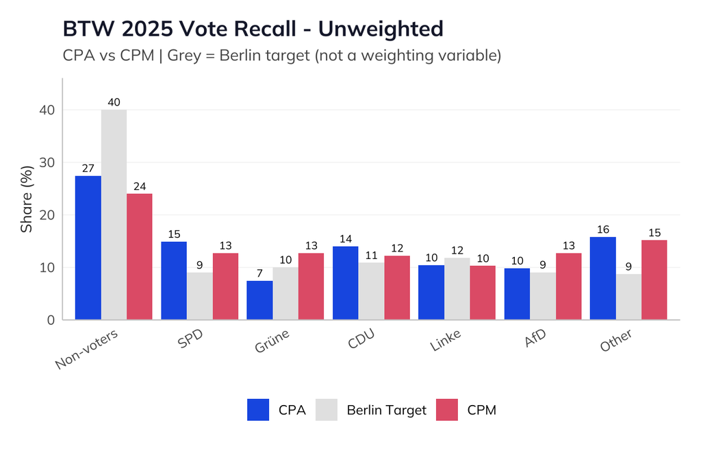

**Takeaway**: Differences in unweighted profiles indicate which demographic groups each sourcing method over- or under-recruits relative to the other. Vote recall is shown for comparison only and is not used as a raking target.

# Weighted Demographic Distributions

After applying Berlin-wide raking weights (age x gender, education, borough), both samples are adjusted toward the same population targets.

## Age

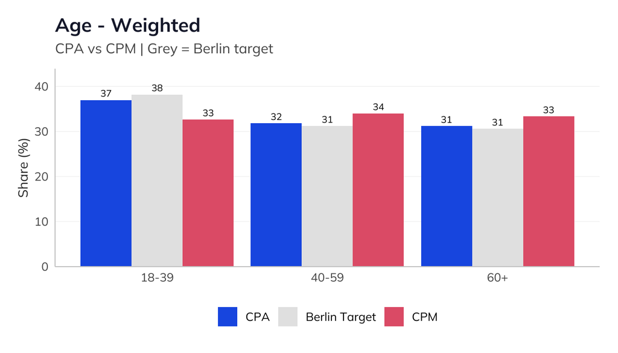

## Gender

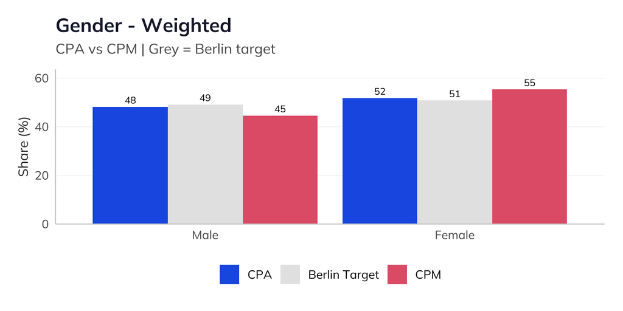

## Borough

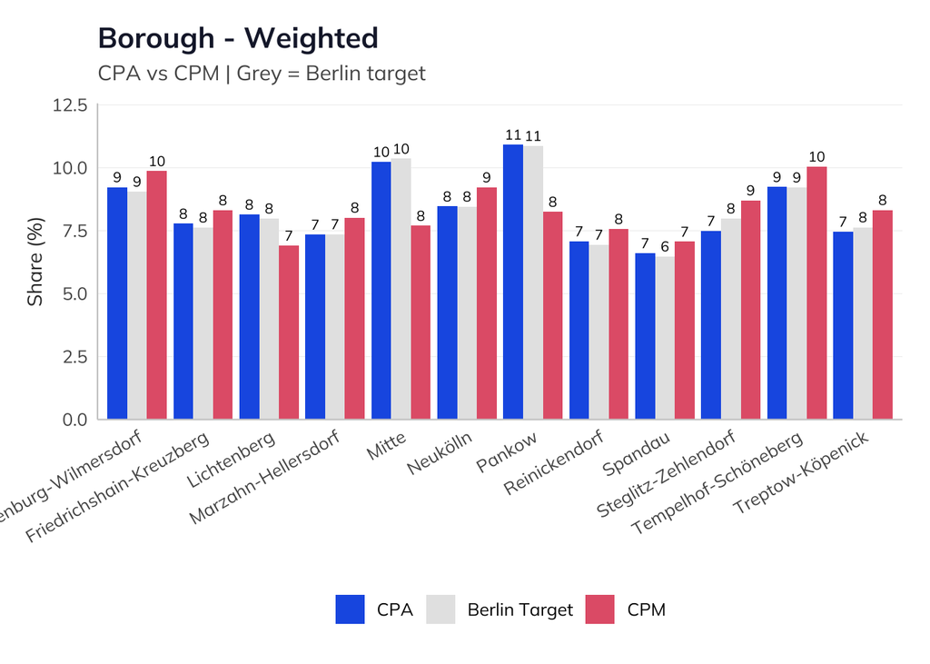

## Education

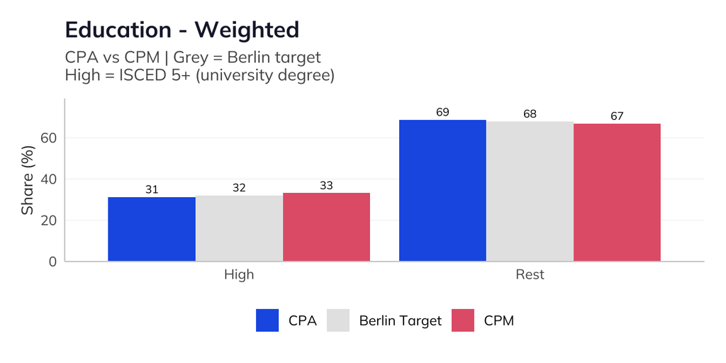

## BTW 2025 Vote Recall

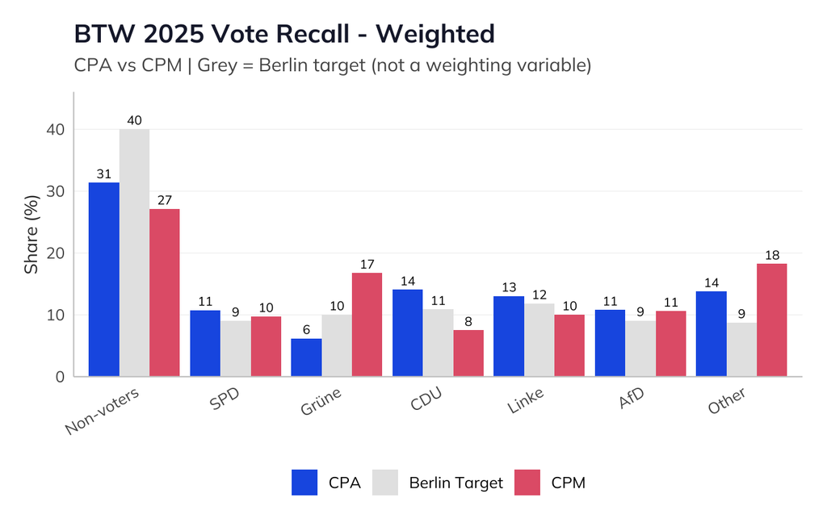

**Takeaway**: After weighting, both samples should converge toward the same population targets on the raked dimensions. Vote recall is not directly targeted by raking — differences here reflect genuine sourcing effects that demographic weighting does not correct.

# Survey Metadata

|  | CPA | CPM |
| --- | --- | --- |
| Project ID | 4595 | 4593 |
| Survey UUID | d6a278b6-93b0-4a49-abb8-01595ab1077b | 85c68723-1b88-4632-a3e8-41a1aff6104f |
| Earliest complete | 2026-01-28 | 2026-01-27 |
| Latest complete | 2026-01-29 | 2026-01-29 |
| Days of fieldwork | 1.2 | 2.1 |
| Date pulled | 2026-01-29 | 2026-01-29 |
| Total respondents (incl. incompletes) | 3,390 | 2,048 |
| Complete respondents | 574 | 333 |
| Number of questions | 14 | 14 |
| Valid Berlin adults (after processing) | 335 | 204 |
| Design effect | 2.29 | 2.08 |
| Effective n | 146 | 98 |
| Weight CV | 1.14 | 1.04 |

# Weighting Specification

| Method | ANES raking (iterative proportional fitting) |
| --- | --- |
| Target universe | Berlin residents aged 18+ |
| Population size (18+) | 3,271,191 |
| Weight cap | 5 |
| Variable 1: Age x Gender | 6 cells |
| Source | Berlin Population Statistics, June 2025 |
| Categories | Female 18-39, Female 40-59, Female 60+, Male 18-39, Male 40-59, Male 60+ |
| Variable 2: Education | 2 categories |
| Source | Zensus 2022 (ISCED classification) |
| Categories | High (ISCED 5+: university degree) vs Rest |
| Variable 3: Borough | 12 districts |
| Source | Berlin Population Statistics, June 2025 |
| Categories | Charlottenburg-Wilmersdorf, Friedrichshain-Kreuzberg, Lichtenberg, Marzahn-Hellersdorf, Mitte, Neukölln, Pankow, Reinickendorf, Spandau, Steglitz-Zehlendorf, Tempelhof-Schöneberg, Treptow-Köpenick |